# 实验1-建立Python开发环境

## 实验一 建立Python开发环境

姓名：谢大伟 学号：9109223004 班级：计算机科学与技术231班

### 一、实验目的

1. 掌握Python解释器和Anaconda开发包的安装和使用方法；
2. 掌握Jupyter Lab和PyCharm的安装和使用方法；
3. 了解Python语言的基本特点以及Python的交互式和脚本式编程方法。

### 二、实验内容

1. 下载和安装Anaconda虚拟环境和Python解释器。
2. 下载和安装Jupyter Lab和PyCharm开发工具。
3. 基于Python SDK自带命令行工具和IDLE体验Python的交互式和脚本式编程。
4. 基于Jupyter Lab和PyCharm体验Python的交互式和脚本式编程。

### 三、实验步骤

1. 下载和安装Anaconda虚拟环境和Python解释器，简要说明安装步骤。

#### 1. 下载 Anaconda

1. 访问 [Anaconda 官方网站](https://www.anaconda.com/products/individual)。
2. 在下载页面中，根据你的操作系统（Windows、macOS 或 Linux）选择合适的安装包。
3. 点击下载按钮，等待安装包下载完成。

#### 2. 安装 Anaconda

##### Windows 系统

1. 双击下载好的安装包，启动安装程序。
2. 阅读并接受许可协议。
3. 选择安装路径（建议使用默认路径）。
4. 选择安装选项：
   - 勾选“Add Anaconda to my PATH environment variable”（可选，但推荐）。
   - 勾选“Register Anaconda as my default Python 3 distribution”（可选，但推荐）。
5. 点击“Install”，等待安装完成。
6. 安装完成后，点击“Next”并完成安装向导。

#### 3. 验证安装

1. 打开终端（Windows 用户可以使用 Anaconda Prompt）。
2. 输入以下命令以验证 Anaconda 是否安装成功：

   ```
   conda --version
   ```

   如果显示版本号，则表示安装成功。
3. 输入以下命令以验证 Python 解释器是否可用：

   ```
   python --version
   ```

   如果显示 Python 版本号，则表示 Python 解释器已成功安装。

#### 4. 创建虚拟环境

1. 打开终端或 Anaconda Prompt。
2. 输入以下命令以创建一个新的虚拟环境（假设环境名为`myenv`）：

   ```
   conda create -n myenv python=3.9
   ```

   （将`3.9`替换为你需要的 Python 版本号）
3. 等待安装完成。
4. 激活虚拟环境：
   - 在 Windows 系统中：

     ```
     conda activate myenv
     ```

   - 在 macOS 或 Linux 系统中：

     ```
     source activate myenv
     ```

5. 输入以下命令以验证虚拟环境是否激活：

   ```
   conda info --envs
   ```

   当前激活的环境前会有一个星号（`*`）。

2. 下载和安装Jupyter Lab和PyCharm开发工具，简要说明安装步骤。

- Anaconda 下载后自带了Jupyter Lab
- 官网下载PyCharm community版本

3. 利用Python SDK自带的IDLE编写程序：输入半径和高度，计算并输出圆柱体的体积。

[figure not shown]

4. 利用于Jupyter Lab或PyCharm编写程序：绘制多个具有公共交点的圆。

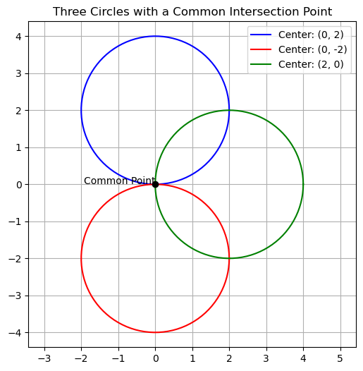

```python
import matplotlib.pyplot as plt
import numpy as np

# 定义一个函数来绘制圆
def draw_circle(center_x, center_y, radius, color='blue'):
    theta = np.linspace(0, 2 * np.pi, 100)  # 参数方程的角度
    x = center_x + radius * np.cos(theta)  # 圆的x坐标
    y = center_y + radius * np.sin(theta)  # 圆的y坐标
    plt.plot(x, y, color=color, label=f"Center: ({center_x}, {center_y})")

# 设置图形
plt.figure(figsize=(6, 6))
plt.title("Three Circles with a Common Intersection Point")
plt.grid(True)
plt.axis("equal")  # 保持比例

# 绘制三个圆，使它们共享一个公共交点
draw_circle(center_x=0, center_y=2, radius=2, color='blue')  # 圆1
draw_circle(center_x=0, center_y=-2, radius=2, color='red')  # 圆2
draw_circle(center_x=2, center_y=0, radius=2, color='green')  # 圆3

# 标记公共交点
plt.plot(0, 0, 'ko')  # 黑色点表示公共交点
plt.text(0, 0, "Common Point", fontsize=10, ha="right")

# 添加图例
plt.legend()

# 显示图形
plt.show()
```

### 四、实验总结

- Anaconda简化了开发环境搭建，Jupyter Lab适合数据分析，PyCharm适合项目开发。
- 交互式编程便于快速测试和学习，脚本式编程适合复杂程序开发。
- 掌握了常用工具的安装与使用，为后续学习打下基础。